# Network Assignment

Dr. Samantha Ajovalasit

### Here you can find some datasets on network

#### https://icon.colorado.edu/#!/networks

#### https://snap.stanford.edu/data/

#### http://konect.cc/

### 0) Clean all data from enivornment and load the igraph library

```r
rm(list = ls())
library(igraph)
```

## 1) Unzip the network.csv.zip file, then load the Dolphin Social Network*

*D. Lusseau et al., “The bottlenose dolphin community of Doubtful Sound features a large proportion of long-lasting associations.” Behavioral Ecology and Sociobiology 54(4), 396-405 (2003)., https://doi.org/10.1007/s00265-003-0651-y [@sci-hub]

### 1.1) load the file “edges.csv” as dataframe and then as graph, load also the nodes as undirected graph

```r
library(igraph)
g1 <- read.csv('dolphin/edges.csv')
g1 <- graph_from_data_frame(g1, directed = F)
g1.nodes <- read.csv('dolphin/nodes.csv')

g1 <- graph_from_data_frame(g1, directed = F,vertices = g1.nodes)
class(g1)
```

### 2) Plot and Save the graph as is, be free to select the format

```r
plot(g1, edge.size=0.00002)
write_graph(g1, 'data/graph/dolphin/dolphin2.gml', format = 'gml')
```

##### 2.1) Load the previous graph

```r
g2 <- read_graph('data/graph/dolphin/dolphin2.gml',format = 'gml')
plot(g2)
```

### 3) Load the florentine families graph and assign as g1

#### You need the library netrank

```r
library('netrankr')
data("florentine_m")
g1 <- (florentine_m)
```

### 3.1) Save florentine families’ graph in gml format

```r
write_graph(g1,'data/graph/florentinefamilies.gml', format = 'gml')
```

### 4) Get all simple information from the graph, number of vertices and edges

```r
str(g1)
```

```r
vcount(g1)
```

```
## [1] 16
```

```r
ecount(g1)
```

```
## [1] 20
```

```r
gsize(g1)
```

```
## [1] 20
```

### 5) Check if the graph is connected

connected means that any two vertices are reachable from each other with a multihop path i.e. not isolated vertices

```r
is.connected(g1)
```

```
## [1] FALSE
```

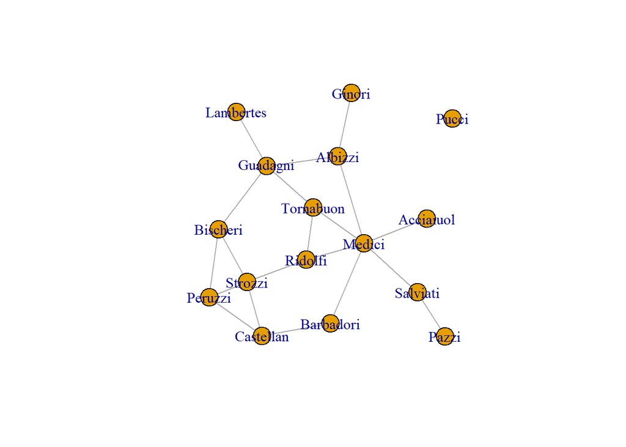

```r
plot(g1)
```

### 6) delete Florentine families with a Null degree and check if is connected

```r
g1.conn <- delete_vertices(g1, which(degree(g1)==0))
g1.conn
is.connected(g1.conn)
plot(g1.conn)
```

[output not shown]

### 7) Plot the graph of florentine families

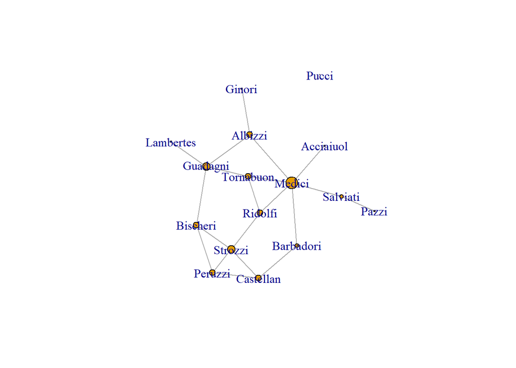

```r
plot(g1, vertex.size= degree(g1)*2)
```

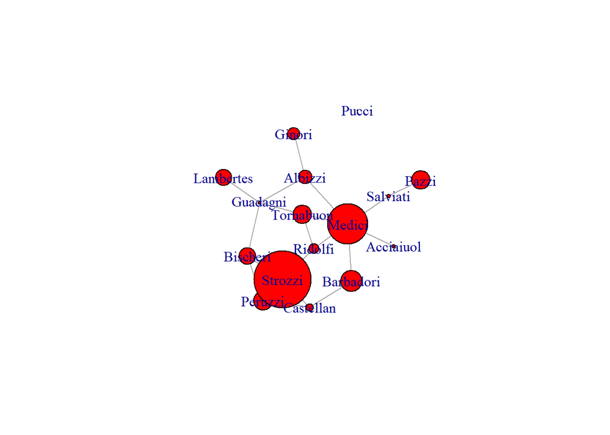

```r
plot(g1, vertex.size= V(g1)$wealth*0.4,
     vertex.color='red')
```

### 8) plot with a different layout

```r
#help('layout_')

lay1 <- layout_(g1, as_tree())
lay2 <- layout_(g1, in_circle())
```

Plot with the two layouts

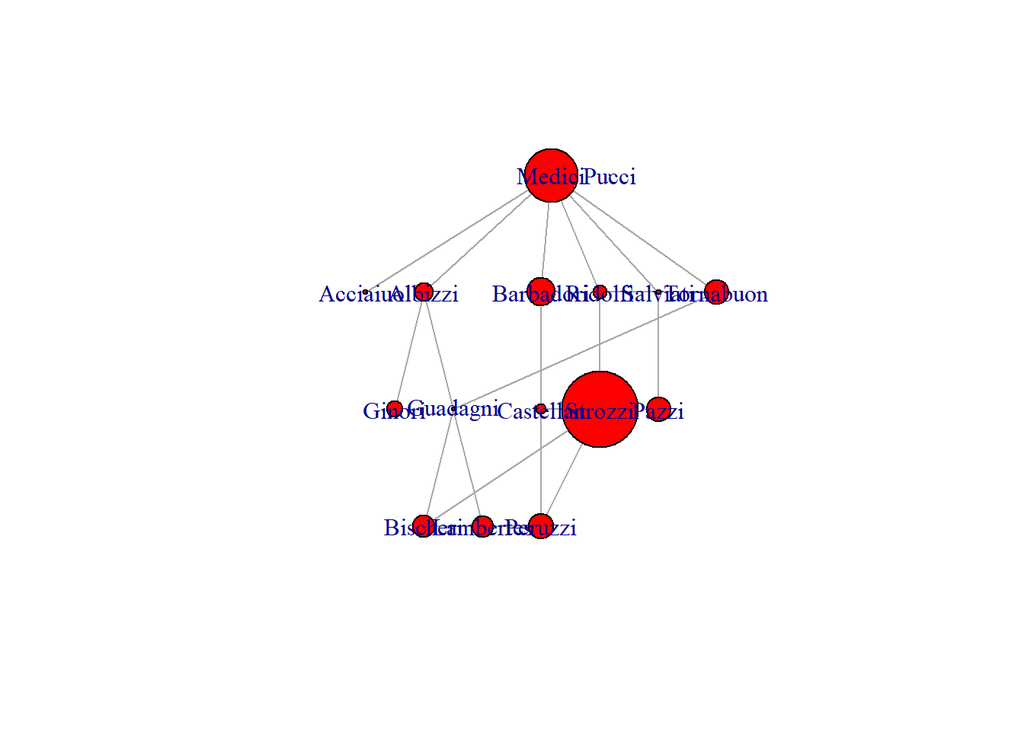

```r
plot(g1, vertex.size= V(g1)$wealth*0.3,
     vertex.color='red', layout=lay1)
```

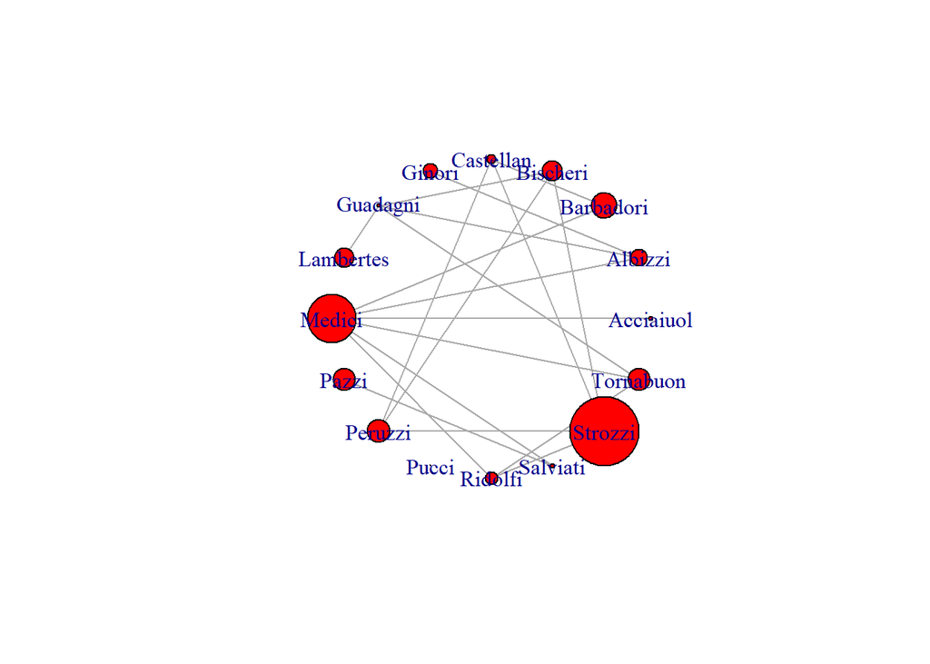

```r
plot(g1, vertex.size= V(g1)$wealth*0.3,
     vertex.color='red', layout=lay2)
```

### 9)Get the Diameter of a graph

The diameter of a graph is the length of the longest geodesic path.

```r
diameter(g1, directed = F)
```

```
## [1] 5
```

```r
diam <- get_diameter(g1, directed=F)
diam
```

```
## + 6/16 vertices, named, from 6886276:
## [1] Bischeri Guadagni Albizzi  Medici   Salviati Pazzi
```

### 10) Get the degree of the graph and plot the graph based the value of the degree

##### Plot the histogram

DEGREE OF A NODE depends if we have a directed or undirected graph if we have a directed one the in degree and the out degree (edges out of vertex) are often different, while if undirected we have bidirectional edges and then they are equal.

High degree nodes attract a lot of connections. They are hubs, very important for the functioning of the network killing high degree nodes may be much more serious than killing low degree nodes

```r
deg <- degree(g1, mode='all')
deg
```

```
## Acciaiuol   Albizzi Barbadori  Bischeri Castellan    Ginori  Guadagni Lambertes
##         1         3         2         3         3         1         4         1
##    Medici     Pazzi   Peruzzi     Pucci   Ridolfi  Salviati   Strozzi Tornabuon
##         6         1         3         0         3         2         4         3
```

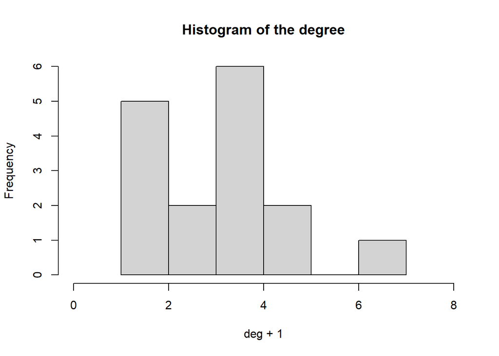

```r
hist(deg+1, xlim=c(0,8), main= 'Histogram of the degree')
```

```r
V(g1)$degs <- deg
```

Plot the graph based on the degree of each vertex

```r
V(g1)$deg
```

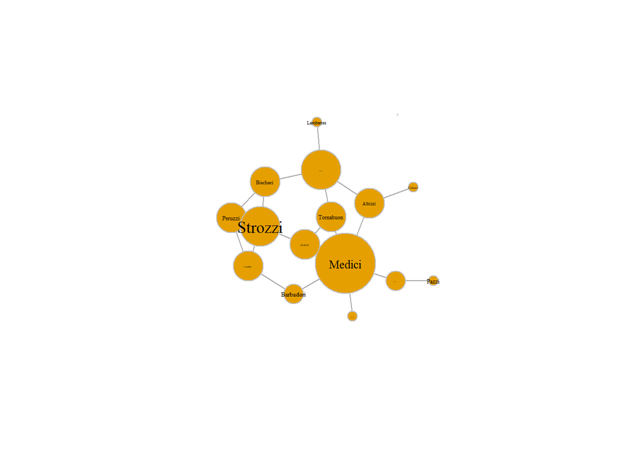

```r
plot.igraph(g1, vertex.size=V(g1)$degs*10,
            vertex.label.cex=V(g1)$wealth*0.0075,
            vertex.label.color="black",
            vertex.frame.color="gray")
```

Plot based on degree distribution

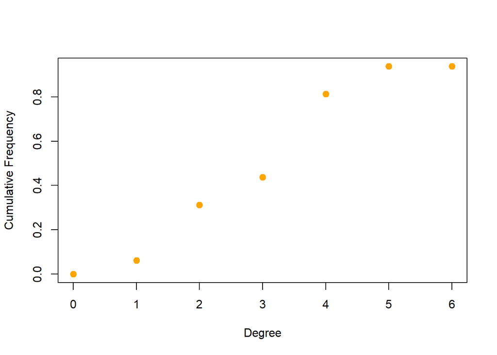

```r
deg.dist <- degree_distribution(g1, cumulative=T, mode="all")
plot( x=0:max(deg), y=1-deg.dist, pch=19, cex=1.2, col="orange", xlab="Degree", ylab="Cumulative Frequency")
```